# AD2 2016.2 - Lab3 - Parte 2

Marianne Linhares

28 de fevereiro de 2016

# Bibliotecas Utlizadas

Primeiramente vamos importar as bibliotecas necessárias para esse script ser executado.

```r
library(dplyr)
library(reshape2)
library(GGally)
library(ggplot2)
library(corrplot)
library(caret)
library(rpart)
library(C50)
library(gmodels)
```

# Descrição da atividade

Nessa etapa você vai aplicar os algoritmos de classificação vistos até agora para prever evasão de alunos no curso de computação.

O cenário é o seguinte: o(a) aluno(a) cursou o primeiro período inteiro e queremos prever se ele(a) se matriculará ou não no segundo período. Se ele(a) não se matriculou é porque abandonou o curso ou solicitou desligamento. De forma mais específica:

1. Separe os dados em treino e teste;
2. Use como atributos as médias das disciplinas mais o atributo que você criou na parte 1 (fique a vontade para criar mais atributos);
3. Treine modelos de regressão logística;
4. Treine modelos de árvore de decisão;
5. Interprete os coeficientes da regressão. Quais atributos parecem ser mais importantes?;
6. Reporte acurácia, precision e recall no treino e teste. Como você avalia os resultados? Justifique sua resposta.

Note que para os passos acima não é necessário usar validação cruzada.

7. Controle overfitting usando validação-cruzada (ridge e lasso na regressão logística e condições de “early stopping” nas árvores de decisão, por exemplo, profundidade da árvore);
8. Reporte acurácia, precision e recall da validação-cruzada e teste (para os melhores modelos);
9. Aplique o melhor modelo a você mesmo(a) usando seu histórico e reporte a predição e resultado.

# 0. Funções auxiliares e variáveis globais

Para preparar e transformar os dados foram usadas as funções e variáveis auxiliares apresentadas nesta seção.

```r
COL_DADOS = c("matricula", "cod_disciplina", "disciplina", "ano", "periodo", "media", "evadiu")

COL_T = c("matricula", "AV", "C1", "IC", "LP1", "LPT", "P1", "evadiu", "ano", "periodo")

NOTA_REP = 5
NOTA_FINAL = 7

INICIO_DISC = 2
FIM_DISC = 7
NUM_DISC = 6

select_treino <- function(ano_periodo) {
  return(as.integer(ano_periodo) >= 20091  & as.integer(ano_periodo) <= 20142)
}

calcula_status <- function(C1, AV, IC, LP1, LPT, P1) {
  return (
    (C1 < NOTA_REP) & (AV < NOTA_REP) & (IC < NOTA_REP) & (LP1 < NOTA_REP) &
    (LPT < NOTA_REP) & (P1 < NOTA_REP)
  )
}

calcula_cra <- function(C1, AV, IC, LP1, LPT, P1) {
  return((C1 + AV + IC + LP1 + LPT + P1)/NUM_DISC)
}

calcula_cra_cc <- function(IC, LP1, P1) {
  return((IC + LP1 + P1)/3)
}

calcula_num_finais <- function(C1, AV, IC, LP1, LPT, P1) {
  return(
    (C1 < NOTA_FINAL) + (AV < NOTA_FINAL) + (IC < NOTA_FINAL) + (LP1 < NOTA_FINAL) +
    (LPT < NOTA_FINAL) + (P1 < NOTA_FINAL)
  )
}

calcula_num_NA <- function(C1, AV, IC, LP1, LPT, P1) {
  return(
    NUM_DISC - (is.finite(C1) + is.finite(AV) + is.finite(IC) + is.finite(LP1) +
    is.finite(LPT) + is.finite(P1))
  )
}

decide_na <- function(col, num, media) {
  return(ifelse(is.na(col), ifelse(num > 3, 0, media), col))
}
```

# 1. Separe os dados em treino e teste

## 1.1 Separando os dados

Para fazer a separação iremos considerar os dados de [2009.1, 2014.2] como treino e [2015.1, 2015.2] como teste. Os demais anos foram retirados, pois vários não apresentaram evasões (isso foi verificado na parte 1) e portanto retirá-los pode diminuir um pouco o desbalanceamento dos dados (Iremos tratar o desbalanceamento na parte 3).

Além disso, não foi feita uma separação aleatória para evitar que tentemos “prever o passado usando o futuro”, além de que uma amostra aleatória poderia ser muito desbalanceada se não particionada corretamente.

```r
# recebe dados
dados <- read.csv('~/DataAnalysis2/lab3/treino.csv')
dados <- na.omit(dados)

# renomeia colunas
colnames(dados) <- COL_DADOS

# cria coluna para auxiliar separação dos dados
dados$ano_periodo <- paste(as.character(dados$ano), as.character(dados$periodo), sep="")

# separação dos dados
dados <- dados %>% mutate(treino=select_treino(ano_periodo))
aux_split <- split(dados, dados$treino)

teste <- aux_split[[1]]
teste <- teste[teste$ano == 2015,] # apenas o ano de 2015 eh considerado

treino <- aux_split[[2]]
```

## 1.2 Transformando as linhas em colunas para facilitar o treinamento do modelo

```r
# Treino

alunos.evadiu <- treino %>%
  group_by(matricula) %>% select(matricula, evadiu, ano, periodo) %>% unique()

treino <- treino %>%
  group_by(matricula, disciplina) %>%
  ungroup() %>%
  select(matricula, disciplina, media) %>%
  mutate(disciplina = as.factor(gsub(" ", ".", disciplina))) %>%
  dcast(matricula ~ disciplina, mean) %>% merge(alunos.evadiu)
colnames(treino) <- COL_T

# Teste

alunos.evadiu <- teste %>%
  group_by(matricula) %>% select(matricula, evadiu, ano, periodo) %>% unique()

teste <- teste %>%
  group_by(matricula, disciplina) %>%
  ungroup() %>%
  select(matricula, disciplina, media) %>%
  mutate(disciplina = as.factor(gsub(" ", ".", disciplina))) %>%
  dcast(matricula ~ disciplina, mean) %>% merge(alunos.evadiu)
colnames(teste) <- COL_T
```

## 1.3 Tratando NAs

Apesar de inicialmente termos retirado as linhas com NA, muitos alunos não apresentam a média de todas as disciplinas, ao trocar as linhas pelas colunas (dcast) essas ausências foram substituídas por NAs.

Assim, foi escolhida a seguinte estratégia para tratar os novos NAs:

- Será criada uma nova coluna contendo o número de NAs por linha. Tal coluna poderá ser utilizada como atributo para a classificação já que é notável o número de NAs nos dados dos alunos que evadem, provavelmente por diferentes motivos (evasão no meio do período, perder a disciplina por falta, etc.)
- Depois disso se o número de NAs for > 3 então substituiremos os NAs por 0, caso contrário serão substituídos pela média das notas presentes

```r
# Treino
treino$num_NA <-
  calcula_num_NA(treino$C1, treino$AV, treino$IC, treino$LP1, treino$LPT, treino$P1)

treino$media_NA <-
  rowMeans(subset(treino, select = c(C1, AV, IC, LP1, LPT, P1)), na.rm = TRUE)

for (i in INICIO_DISC:FIM_DISC) {
  treino[, i] <- decide_na(treino[, i], treino$num_NA, treino$media_NA)
}

treino <- subset(treino, select = -c(media_NA, ano, periodo))

# Teste
teste$num_NA <- calcula_num_NA(teste$C1, teste$AV, teste$IC, teste$LP1, teste$LPT, teste$P1)

teste$media_NA <- rowMeans(subset(teste, select = c(C1, AV, IC, LP1, LPT, P1)), na.rm = TRUE)

for (i in INICIO_DISC:FIM_DISC) {
  teste[, i] <- decide_na(teste[, i], teste$num_NA, teste$media_NA)
}

teste <- subset(teste, select = -c(media_NA, ano, periodo))
```

# 2. Use como atributos as médias das disciplinas mais o atributo que você criou na parte 1 (fique a vontade para criar mais atributos)

# 2.1 Adicionando atributos

Iremos adicionar as variáveis utilizadas na parte 1 da atividade, de modo que após essas transformações os dados de treino e teste estarão prontos para serem usados para gerar e testar modelos, e terão as seguintes colunas:

- matricula: identificador do aluno
- AV: média em Álgebra Vetorial
- C1: média em Cálculo 1
- IC: média em Introdução a Computação
- LP1: média em Lab. de Programação 1
- LPT: média em Leitura e Produção de Texto
- P1: média em Programação 1
- evadiu: variável de classificação
- num_NA: número de NAs
- status: TRUE se reprovou todas as disciplinas
- cra: média das disciplinas
- cra_cc: média nas disciplinas de cc
- num_finais: número de finais feitas

```r
# Treino
treino$status <-
  calcula_status(treino$C1, treino$AV, treino$IC, treino$LP1, treino$LPT, treino$P1)

treino$cra <-
  calcula_cra(treino$C1, treino$AV, treino$IC, treino$LP1, treino$LPT, treino$P1)

treino$cra_cc <-
  calcula_cra_cc(treino$IC, treino$LP1, treino$P1)

treino$num_finais <-
  calcula_num_finais(treino$C1, treino$AV, treino$IC, treino$LP1, treino$LPT, treino$P1)

# Teste
teste$status <-
  calcula_status(teste$C1, teste$AV, teste$IC, teste$LP1, teste$LPT, teste$P1)

teste$cra <-
  calcula_cra(teste$C1, teste$AV, teste$IC, teste$LP1, teste$LPT, teste$P1)

teste$cra_cc <-
  calcula_cra_cc(teste$IC, teste$LP1, teste$P1)

teste$num_finais <-
  calcula_num_finais(teste$C1, teste$AV, teste$IC, teste$LP1, teste$LPT, teste$P1)
```

## 2.2 Verificando desbalanceamento no treino

Nesta parte do laboratório não iremos tratar o desbalanceamento, mas iremos analisar o quão desbalanceados estão os dados de treino buscando escolher um conjunto de dados de treino que o minimize.

```r
num_evasoes <- treino %>% summarise(num_evasoes = sum(evadiu), num_alunos = n())

# gráfico
num_evasoes.melt <- num_evasoes %>% melt()
```

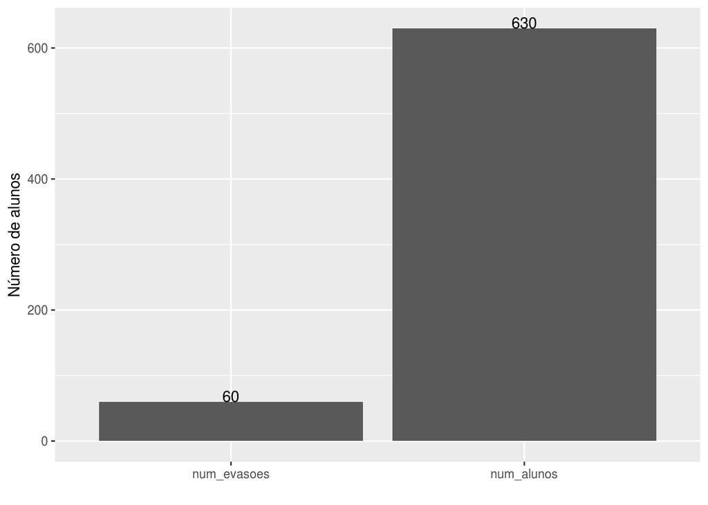

```r
ggplot(num_evasoes.melt, aes(x = factor(variable), y = value)) + geom_bar(stat="identity") +
  geom_text(aes(label= value), vjust=0) + xlab("") + ylab("Número de alunos")
```

# 2.3 Modelos utilizados

Para os próximos passos iremos usar os dados de treino para gerar modelos de classificação para os dados e validar a acurácia utilizando os dados de teste.

Iremos utilizar 2 modelos:

- Modelo global: um modelo que não utiliza as médias das disciplinas para a classificação, mas apenas atributos que poderiam ser utilizados para qualquer curso. Portanto iremos utilizar os atributos: cra, status, num_NA, num_finais.
- Modelo computação: um modelo que além dos atributos do modelo global também leva em conta a média das disciplinas do primeiro período de Ciência da Computação.

Assim, com os próximos passos teremos uma noção de qual modelo se sai melhor e se levar a média das disciplinas individualmente tem um impacto notável no classificador.

# 3. Treine modelos de regressão logística

Regressão Logística é um modelo de regressão em que a variável dependente é categórica (ou seja discreta), o funcionamento para geração do modelo é similiar a regressão linear, mas não buscamos uma função que se adeque (tenha menor erro) aos dados, e sim uma função que melhor “separe” os dados de forma a classificá-los.

Para treinar um modelo de regressão logística no R iremos usar a função glm.

## 3.1 Modelo global

```r
treino$evadiu <- factor(treino$evadiu)
treino$status <- factor(treino$status)

teste$evadiu <- factor(teste$evadiu)
teste$status <- factor(teste$status)

model.reg.global <- train(evadiu ~ cra + num_NA + status + num_finais,
                          data=treino, method="glm", family="binomial", na.action = na.omit)

pred.reg.global <- predict(model.reg.global, newdata=teste)
treino.pred.reg.global <- predict(model.reg.global, newdata=treino)

acc.reg.global <- confusionMatrix(pred.reg.global, teste$evadiu)
acc.reg.global
```

```
## Confusion Matrix and Statistics
##
##           Reference
## Prediction FALSE TRUE
##      FALSE   167    3
##      TRUE      5   14
##
##                Accuracy : 0.9577
##                  95% CI : (0.9183, 0.9816)
##     No Information Rate : 0.9101
##     P-Value [Acc > NIR] : 0.009832
##
##                   Kappa : 0.7545
##  Mcnemar's Test P-Value : 0.723674
##
##             Sensitivity : 0.9709
##             Specificity : 0.8235
##          Pos Pred Value : 0.9824
##          Neg Pred Value : 0.7368
##              Prevalence : 0.9101
##          Detection Rate : 0.8836
##    Detection Prevalence : 0.8995
##       Balanced Accuracy : 0.8972
##
##        'Positive' Class : FALSE
##
```

## 3.2 Modelo computação

```r
model.reg.cc <- train(evadiu ~ cra + num_NA + status + num_finais + C1 + AV +
                      IC + LP1 + LPT + P1 + cra_cc,
                       data=treino,
                       method="glm",
                       family="binomial",
                       na.action = na.omit)
```

[output not shown]

[output cut: 19 more lines]

[output not shown]

```r
pred.reg.cc <- predict(model.reg.cc, newdata=teste)
treino.pred.reg.cc <- predict(model.reg.cc, newdata=treino)
acc.reg.cc <- confusionMatrix(pred.reg.cc, teste$evadiu)
acc.reg.cc
```

```
## Confusion Matrix and Statistics
##
##           Reference
## Prediction FALSE TRUE
##      FALSE   167    3
##      TRUE      5   14
##
##                Accuracy : 0.9577
##                  95% CI : (0.9183, 0.9816)
##     No Information Rate : 0.9101
##     P-Value [Acc > NIR] : 0.009832
##
##                   Kappa : 0.7545
##  Mcnemar's Test P-Value : 0.723674
##
##             Sensitivity : 0.9709
##             Specificity : 0.8235
##          Pos Pred Value : 0.9824
##          Neg Pred Value : 0.7368
##              Prevalence : 0.9101
##          Detection Rate : 0.8836
##    Detection Prevalence : 0.8995
##       Balanced Accuracy : 0.8972
##
##        'Positive' Class : FALSE
##
```

## 3.3 Conclusão

Avaliando apenas a acurácia nos testes vemos que ambos tem a mesma acurácia. A precisão e recall serão calculados (tanto para treino quanto para teste) e comparados conjuntamente entre vários modelos na Seção 6.

# 4. Treine modelos de árvore de decisão

## 4.1 Modelo global

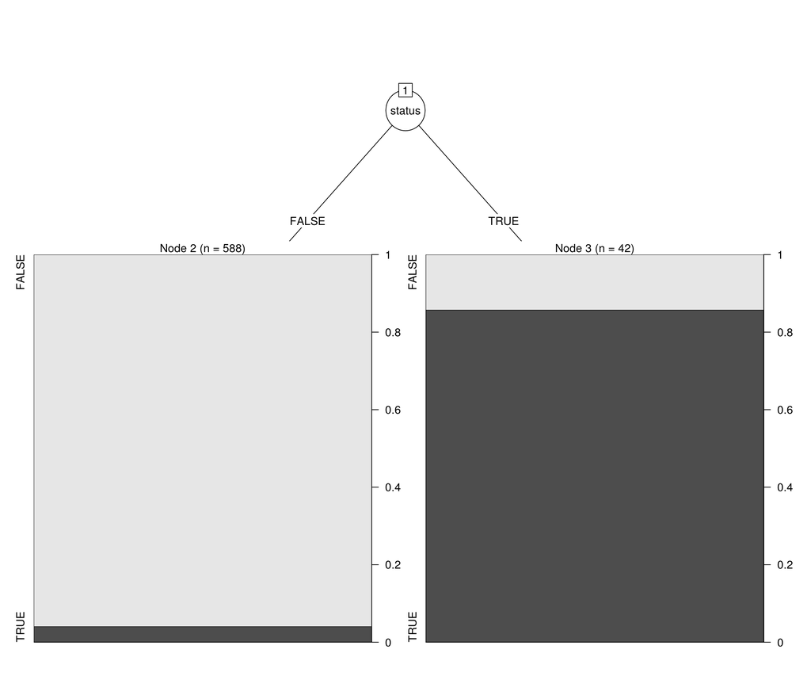

```r
model.tree.global <- C5.0(evadiu ~ num_finais + num_NA + cra + status, data = treino)
plot(model.tree.global)
```

```r
pred.tree.global <- predict(model.tree.global, teste, type='class')
treino.pred.tree.global <- predict(model.tree.global, treino, type='class')

acc.tree.global <- confusionMatrix(pred.tree.global, teste$evadiu)
acc.tree.global
```

```
## Confusion Matrix and Statistics
##
##           Reference
## Prediction FALSE TRUE
##      FALSE   167    3
##      TRUE      5   14
##
##                Accuracy : 0.9577
##                  95% CI : (0.9183, 0.9816)
##     No Information Rate : 0.9101
##     P-Value [Acc > NIR] : 0.009832
##
##                   Kappa : 0.7545
##  Mcnemar's Test P-Value : 0.723674
##
##             Sensitivity : 0.9709
##             Specificity : 0.8235
##          Pos Pred Value : 0.9824
##          Neg Pred Value : 0.7368
##              Prevalence : 0.9101
##          Detection Rate : 0.8836
##    Detection Prevalence : 0.8995
##       Balanced Accuracy : 0.8972
##
##        'Positive' Class : FALSE
##
```

## 4.2 Modelo computação

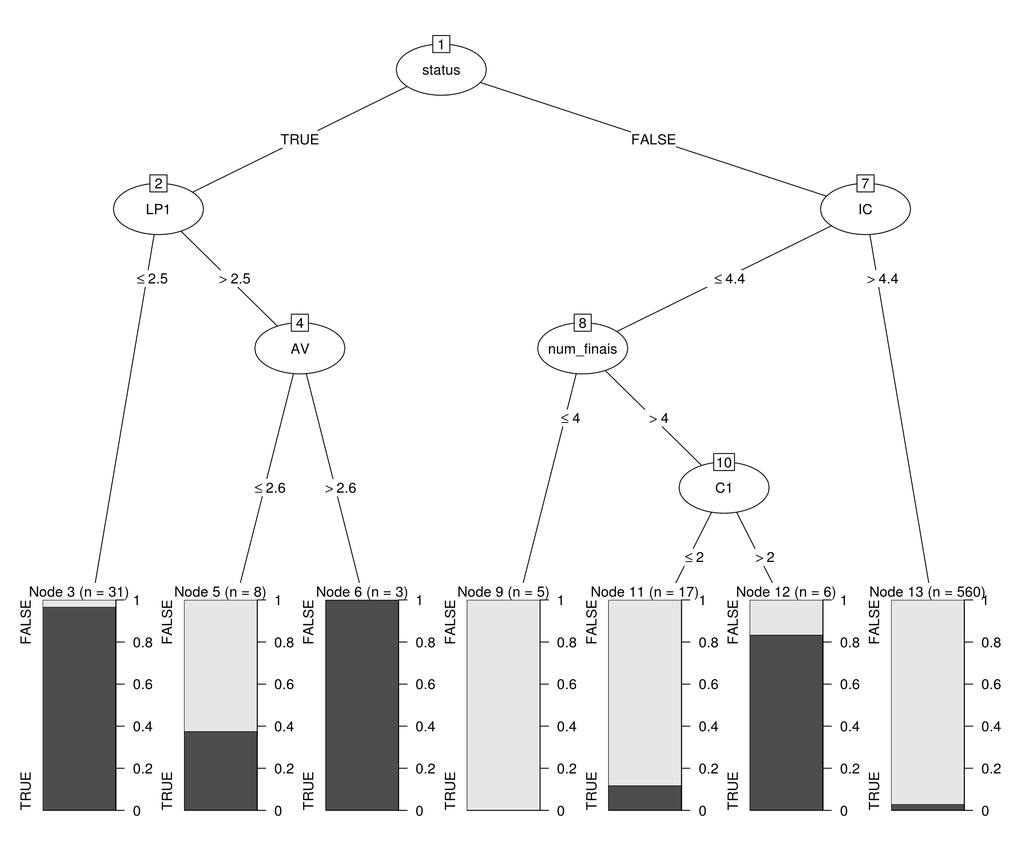

```r
model.tree.cc <-  C5.0(evadiu ~ cra + num_NA + status + num_finais + C1 + AV +
                      IC + LP1 + LPT + P1 + cra_cc, data = treino)
plot(model.tree.cc)
```

```r
pred.tree.cc <- predict(model.tree.cc, teste, type='class')
treino.pred.tree.cc <- predict(model.tree.cc, treino, type='class')

acc.tree.cc <- confusionMatrix(pred.tree.cc, teste$evadiu)
acc.tree.cc
```

```
## Confusion Matrix and Statistics
##
##           Reference
## Prediction FALSE TRUE
##      FALSE   167    4
##      TRUE      5   13
##
##                Accuracy : 0.9524
##                  95% CI : (0.9115, 0.978)
##     No Information Rate : 0.9101
##     P-Value [Acc > NIR] : 0.02137
##
##                   Kappa : 0.7166
##  Mcnemar's Test P-Value : 1.00000
##
##             Sensitivity : 0.9709
##             Specificity : 0.7647
##          Pos Pred Value : 0.9766
##          Neg Pred Value : 0.7222
##              Prevalence : 0.9101
##          Detection Rate : 0.8836
##    Detection Prevalence : 0.9048
##       Balanced Accuracy : 0.8678
##
##        'Positive' Class : FALSE
##
```

## 4.3 Conclusão

Considerando apenas acurácia, o modelo global se saiu melhor com acurácia de ~95.77% enquanto o modelo computação obteve acurácia de ~95.24%. No entanto a diferença é bem pequena.

# 5. Interprete os coeficientes da regressão. Quais atributos parecem ser mais importantes?

```r
summary(model.reg.global)
```

```
##
## Call:
## NULL
##
## Deviance Residuals:
##     Min       1Q   Median       3Q      Max
## -2.1944  -0.2634  -0.2206  -0.1817   2.8828
##
## Coefficients:
##             Estimate Std. Error z value Pr(>|z|)
## (Intercept)   0.9164     1.7375   0.527 0.597909
## cra          -0.6096     0.1957  -3.115 0.001842 **
## num_NA        0.1059     0.1579   0.671 0.502485
## statusTRUE    2.4058     0.6378   3.772 0.000162 ***
## num_finais   -0.1812     0.2168  -0.835 0.403451
## ---
## Signif. codes:  0 '***' 0.001 '**' 0.01 '*' 0.05 '.' 0.1 ' ' 1
##
## (Dispersion parameter for binomial family taken to be 1)
##
##     Null deviance: 396.26  on 629  degrees of freedom
## Residual deviance: 209.97  on 625  degrees of freedom
## AIC: 219.97
##
## Number of Fisher Scoring iterations: 6
```

```r
summary(model.reg.cc)
```

```
##
## Call:
## NULL
##
## Deviance Residuals:
##     Min       1Q   Median       3Q      Max
## -2.0086  -0.2706  -0.2086  -0.1630   2.9851
##
## Coefficients: (2 not defined because of singularities)
##              Estimate Std. Error z value Pr(>|z|)
## (Intercept)  2.624264   1.945237   1.349   0.1773
## cra         -2.594655   2.006185  -1.293   0.1959
## num_NA      -0.000685   0.180980  -0.004   0.9970
## statusTRUE   1.867198   0.801056   2.331   0.0198 *
## num_finais  -0.271367   0.219430  -1.237   0.2162
## C1           0.315905   0.362808   0.871   0.3839
## AV           0.528855   0.338882   1.561   0.1186
## IC           0.357497   0.388793   0.920   0.3578
## LP1          0.472461   0.629596   0.750   0.4530
## LPT          0.118268   0.362583   0.326   0.7443
## P1                 NA         NA      NA       NA
## cra_cc             NA         NA      NA       NA
## ---
## Signif. codes:  0 '***' 0.001 '**' 0.01 '*' 0.05 '.' 0.1 ' ' 1
##
## (Dispersion parameter for binomial family taken to be 1)
##
##     Null deviance: 396.26  on 629  degrees of freedom
## Residual deviance: 198.84  on 620  degrees of freedom
## AIC: 218.84
##
## Number of Fisher Scoring iterations: 6
```

```r
summary(model.tree.global)
```

```
##
## Call:
## C5.0.formula(formula = evadiu ~ num_finais + num_NA + cra + status, data
##  = treino)
##
##
## C5.0 [Release 2.07 GPL Edition]      Fri Mar  3 19:59:11 2017
## -------------------------------
##
## Class specified by attribute `outcome'
##
## Read 630 cases (5 attributes) from undefined.data
##
## Decision tree:
##
## status = FALSE: FALSE (588/24)
## status = TRUE: TRUE (42/6)
##
##
## Evaluation on training data (630 cases):
##
##      Decision Tree
##    ----------------
##    Size      Errors
##
##       2   30( 4.8%)   <<
##
##
##     (a)   (b)    <-classified as
##    ----  ----
##     564     6    (a): class FALSE
##      24    36    (b): class TRUE
##
##
##  Attribute usage:
##
##  100.00% status
##
##
## Time: 0.0 secs
```

```r
summary(model.tree.cc)
```

```
##
## Call:
## C5.0.formula(formula = evadiu ~ cra + num_NA + status + num_finais + C1
##  + AV + IC + LP1 + LPT + P1 + cra_cc, data = treino)
##
##
## C5.0 [Release 2.07 GPL Edition]      Fri Mar  3 19:59:11 2017
## -------------------------------
##
## Class specified by attribute `outcome'
##
## Read 630 cases (12 attributes) from undefined.data
##
## Decision tree:
##
## status = TRUE:
## :...LP1 <= 2.5: TRUE (31/1)
## :   LP1 > 2.5:
## :   :...AV <= 2.6: FALSE (8/3)
## :       AV > 2.6: TRUE (3)
## status = FALSE:
## :...IC > 4.4: FALSE (560/17)
##     IC <= 4.4:
##     :...num_finais <= 4: FALSE (5)
##         num_finais > 4:
##         :...C1 <= 2: FALSE (17/2)
##             C1 > 2: TRUE (6/1)
##
##
## Evaluation on training data (630 cases):
##
##      Decision Tree
##    ----------------
##    Size      Errors
##
##       7   24( 3.8%)   <<
##
##
##     (a)   (b)    <-classified as
##    ----  ----
##     568     2    (a): class FALSE
##      22    38    (b): class TRUE
##
##
##  Attribute usage:
##
##  100.00% status
##   93.33% IC
##    6.67% LP1
##    4.44% num_finais
##    3.65% C1
##    1.75% AV
##
##
## Time: 0.0 secs
```

Segundo as árvores de decisão, Status sem dúvidas é o atributo mais importante sendo utilizado 100% das vezes, ou seja em toda decisão o Status é avaliado, inclusive sendo o único atributo avaliado na árvore de decisão do modelo global e ainda sim obtendo maior acurácia que a árvore mais “complexa”. Outro atributo evidenciado pela árvore do modelo computação é a média em IC.

Já segundo as regressões logísticas Status também é uma das variáveis mais importantes, seguida por CRA no modelo global.

Aparentemente alguns dos demais atributos adicionados (como: num_NA, LPT, …) não estão ajudando muito na classificação e seu uso podem ser repensados para a próxima parte da atividade.

# 6. Reporte acurácia, precision e recall no treino e teste. Como você avalia os resultados? Justifique sua resposta.

Antes de analisar esses parâmetros, irei rapidamente explicar seu significado e o que implica para esta análise em específico.

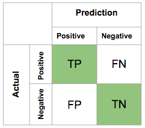

- Acurácia: quanto por cento acertamos sobre o total, ou seja: (TP+TN)/(TP + FN + FP + TN)
- Precisão: quanto por cento dos que previmos que EVADIU realmente evadiram: TP/(TP + FP)
- Recall: quanto por cento dos que evadiram nós previmos como EVADIU: TP/(TP + FN)

Portanto queremos um modelo com uma maior acurácia, precisão e recall. Priorizando acurácia e recall, pois prever que X irá evadir e X não evade é menos “grave” do que prever que Y não irá evadir, mas Y evade.

## 6.1 No treino

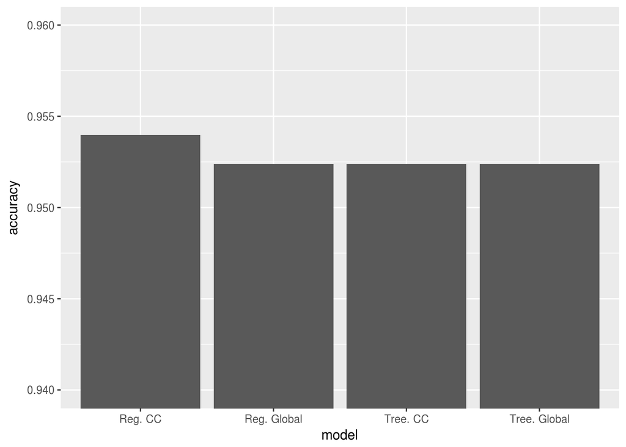

```r
# Calculando
treino.reg.global <- confusionMatrix(treino.pred.reg.global, treino$evadiu)
treino.reg.cc <- confusionMatrix(treino.pred.reg.cc, treino$evadiu)

treino.tree.global <- confusionMatrix(treino.pred.tree.global, treino$evadiu)
treino.tree.cc <- confusionMatrix(treino.pred.tree.global, treino$evadiu)


# Acurácia
df <- data_frame('accuracy' = c(treino.reg.global$overall['Accuracy'],
                                treino.reg.cc$overall['Accuracy'],
                                treino.tree.global$overall['Accuracy'],
                                treino.tree.cc$overall['Accuracy']),
                 'model' = c('Reg. Global', 'Reg. CC', 'Tree. Global', 'Tree. CC'))

ggplot(data = df, aes(x=model, y=accuracy)) + geom_bar(stat="identity") + coord_cartesian(ylim=c(0.94, 0.96))
```

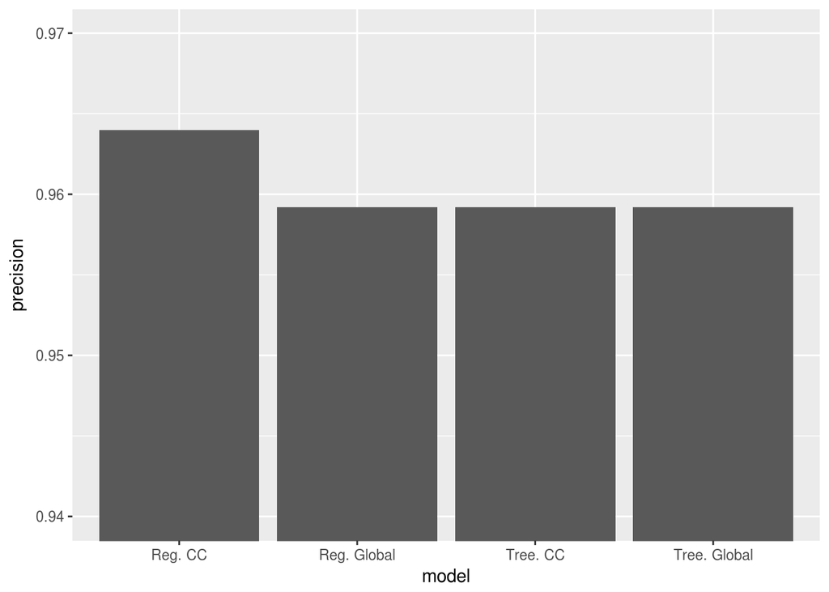

```r
# Precisão
df <- data_frame('precision' = c(treino.reg.global$byClass['Precision'],
                                treino.reg.cc$byClass['Precision'],
                                treino.tree.global$byClass['Precision'],
                                treino.tree.cc$byClass['Precision']),
                 'model' = c('Reg. Global', 'Reg. CC', 'Tree. Global', 'Tree. CC'))


ggplot(data = df, aes(x=model, y=precision)) + geom_bar(stat="identity") + coord_cartesian(ylim=c(0.94, 0.97))
```

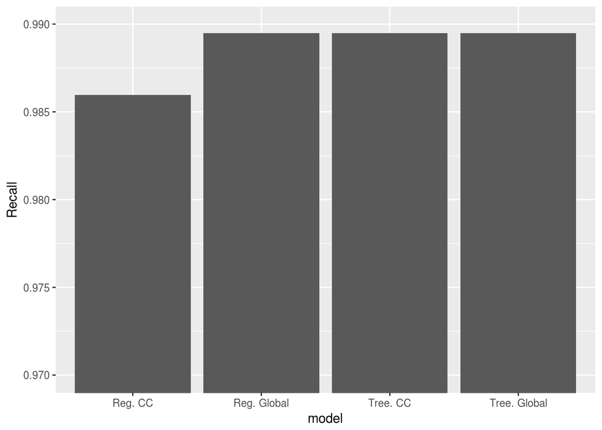

```r
# Recall
df <- data_frame('Recall' = c(treino.reg.global$byClass['Recall'],
                                treino.reg.cc$byClass['Recall'],
                                treino.tree.global$byClass['Recall'],
                                treino.tree.cc$byClass['Recall']),
                 'model' = c('Reg. Global', 'Reg. CC', 'Tree. Global', 'Tree. CC'))


ggplot(data = df, aes(x=model, y=Recall)) + geom_bar(stat="identity") + coord_cartesian(ylim=c(0.97, 0.99))
```

## 6.2 No teste

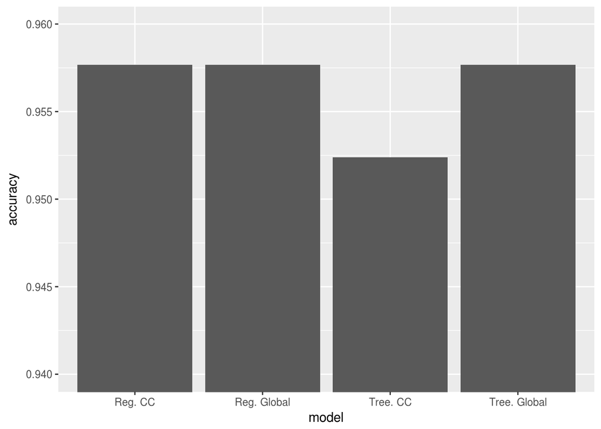

```r
# Acurácia
df <- data_frame('accuracy' = c(acc.reg.global$overall['Accuracy'],
                                acc.reg.cc$overall['Accuracy'],
                                acc.tree.global$overall['Accuracy'],
                                acc.tree.cc$overall['Accuracy']),
                 'model' = c('Reg. Global', 'Reg. CC', 'Tree. Global', 'Tree. CC'))

ggplot(data = df, aes(x=model, y=accuracy)) + geom_bar(stat="identity") + coord_cartesian(ylim=c(0.94, 0.96))
```

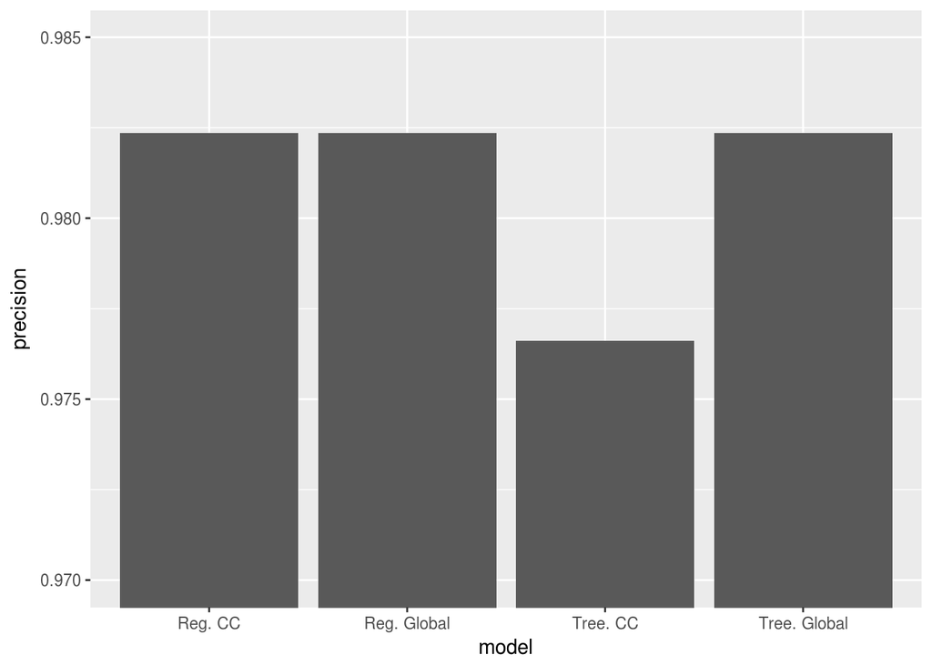

```r
# Precisão
df <- data_frame('precision' = c(acc.reg.global$byClass['Precision'],
                                acc.reg.cc$byClass['Precision'],
                                acc.tree.global$byClass['Precision'],
                                acc.tree.cc$byClass['Precision']),
                 'model' = c('Reg. Global', 'Reg. CC', 'Tree. Global', 'Tree. CC'))


ggplot(data = df, aes(x=model, y=precision)) + geom_bar(stat="identity") + coord_cartesian(ylim=c(0.97, 0.985))
```

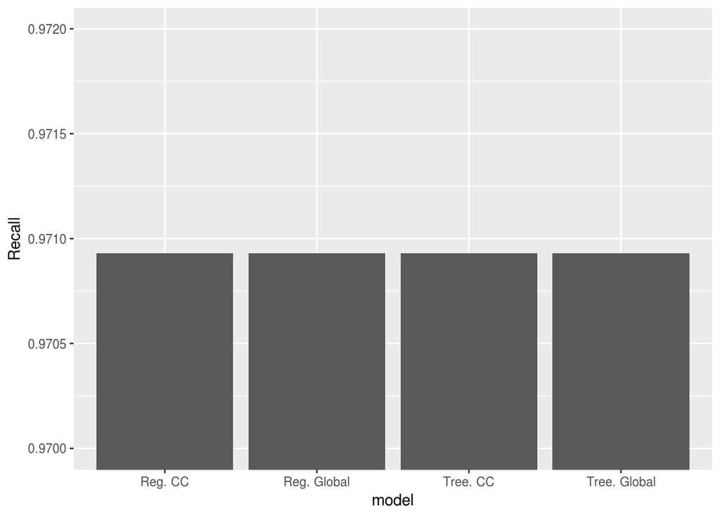

```r
# Recall
df <- data_frame('Recall' = c(acc.reg.global$byClass['Recall'],
                                acc.reg.cc$byClass['Recall'],
                                acc.tree.global$byClass['Recall'],
                                acc.tree.cc$byClass['Recall']),
                 'model' = c('Reg. Global', 'Reg. CC', 'Tree. Global', 'Tree. CC'))


ggplot(data = df, aes(x=model, y=Recall)) + geom_bar(stat="identity") + coord_cartesian(ylim=c(0.97, 0.972))
```

*Treino*

*Teste*

Já no teste novamente todos os modelos apresentam resultados bem similares, com acurácia ~0.957, precisão de ~0.982 e recall de ~0.971, e apenas um apresentou precisão e acurácia levemente menor que os demais.

# 7. Controle overfitting usando validação-cruzada (ridge e lasso na regressão logística e condições de “early stopping” nas árvores de decisão, por exemplo, profundidade da árvore)

## 7.1 Usando regressão logística

### 7.1.1 Modelo global

```r
ctrl <- trainControl(method = "repeatedcv", number = 10, savePredictions = TRUE)

ctr.model.reg.global <- train(evadiu ~ cra + num_NA + status + num_finais,
                   data=treino,
                   method="glm",
                   family="binomial",
                   trControl=ctrl,
                   na.action = na.omit)

pred.ctr.reg.global <- predict(ctr.model.reg.global, teste)
treino.ctr.reg.global <- predict(ctr.model.reg.global, treino)

acc.ctr.reg.global <- confusionMatrix(pred.ctr.reg.global, teste$evadiu)
acc.ctr.reg.global
```

```
## Confusion Matrix and Statistics
##
##           Reference
## Prediction FALSE TRUE
##      FALSE   167    3
##      TRUE      5   14
##
##                Accuracy : 0.9577
##                  95% CI : (0.9183, 0.9816)
##     No Information Rate : 0.9101
##     P-Value [Acc > NIR] : 0.009832
##
##                   Kappa : 0.7545
##  Mcnemar's Test P-Value : 0.723674
##
##             Sensitivity : 0.9709
##             Specificity : 0.8235
##          Pos Pred Value : 0.9824
##          Neg Pred Value : 0.7368
##              Prevalence : 0.9101
##          Detection Rate : 0.8836
##    Detection Prevalence : 0.8995
##       Balanced Accuracy : 0.8972
##
##        'Positive' Class : FALSE
##
```

### 7.1.2 Modelo computação

```r
ctrl <- trainControl(method = "repeatedcv", number = 10, savePredictions = TRUE)

ctr.model.reg.cc <- train(evadiu ~ cra + num_NA + status + num_finais + C1 + AV +
                      IC + LP1 + LPT + P1 + cra_cc,
                   data=treino,
                   method="glm",
                   family="binomial",
                   trControl=ctrl,
                   na.action = na.omit)
pred.ctr.reg.cc <- predict(ctr.model.reg.cc, teste)
treino.ctr.reg.cc <- predict(ctr.model.reg.cc, treino)
acc.ctr.reg.cc <- confusionMatrix(pred.ctr.reg.cc, teste$evadiu)
acc.ctr.reg.cc
```

```
## Confusion Matrix and Statistics
##
##           Reference
## Prediction FALSE TRUE
##      FALSE   167    3
##      TRUE      5   14
##
##                Accuracy : 0.9577
##                  95% CI : (0.9183, 0.9816)
##     No Information Rate : 0.9101
##     P-Value [Acc > NIR] : 0.009832
##
##                   Kappa : 0.7545
##  Mcnemar's Test P-Value : 0.723674
##
##             Sensitivity : 0.9709
##             Specificity : 0.8235
##          Pos Pred Value : 0.9824
##          Neg Pred Value : 0.7368
##              Prevalence : 0.9101
##          Detection Rate : 0.8836
##    Detection Prevalence : 0.8995
##       Balanced Accuracy : 0.8972
##
##        'Positive' Class : FALSE
##
```

### 7.1.3 Conclusão

Avaliando apenas a acurácia nos testes vemos que ambos tem a mesma acurácia. A precisão e recall serão calculados e comparados conjuntamente entre vários modelos na Seção 8.

## 7.2 Usando árvore de decisão

Foi treinado um modelo utilizando earlyStopping e controlando a altura da árvore, porém a altura da árvore já está “pequena” (2), portanto esses métodos não mostraram melhoras no modelo. Bucando uma melhora, foi utilizada uma nova biblioteca para gerar a árvore: rpart.

Segundo a documentação de rpart é utilizada cross-validation entre outros métodos para garantir um melhor resultado na geração do modelo, mais detalhes em [4].

### 7.2.1 Modelo global

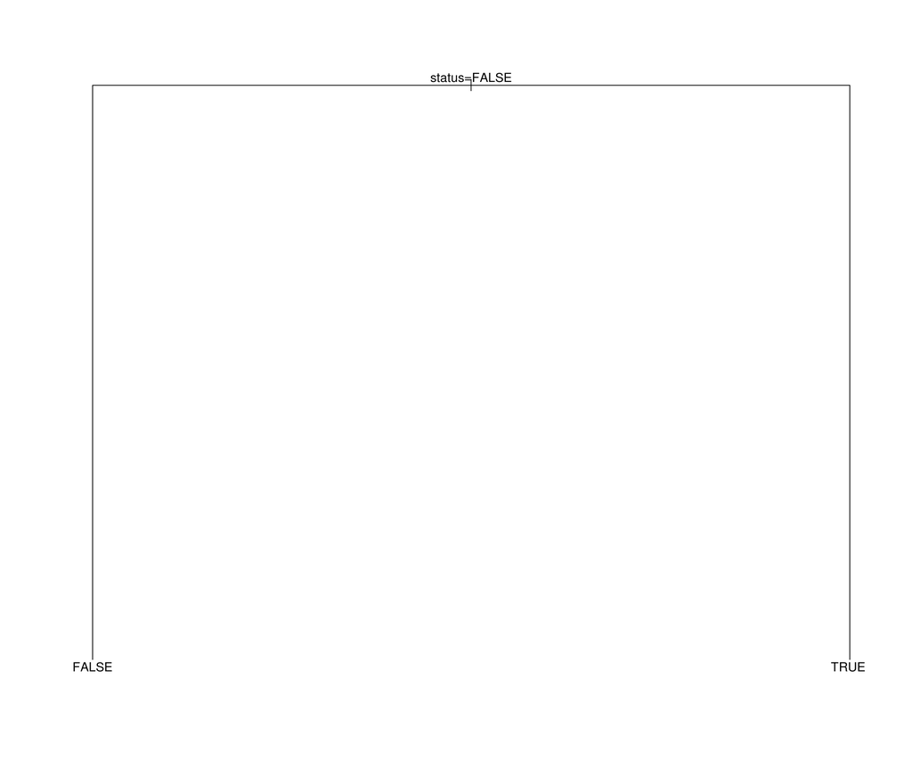

```r
model.rp.global <- rpart(evadiu ~ cra + num_NA + status + num_finais, data = treino, method = 'class')

plot(model.rp.global)
text(model.rp.global, pretty=0)
```

```r
pred.rp.global <- predict(model.rp.global, teste, type='class')

acc.rp.global <- confusionMatrix(pred.rp.global, teste$evadiu)
acc.rp.global
```

```
## Confusion Matrix and Statistics
##
##           Reference
## Prediction FALSE TRUE
##      FALSE   167    3
##      TRUE      5   14
##
##                Accuracy : 0.9577
##                  95% CI : (0.9183, 0.9816)
##     No Information Rate : 0.9101
##     P-Value [Acc > NIR] : 0.009832
##
##                   Kappa : 0.7545
##  Mcnemar's Test P-Value : 0.723674
##
##             Sensitivity : 0.9709
##             Specificity : 0.8235
##          Pos Pred Value : 0.9824
##          Neg Pred Value : 0.7368
##              Prevalence : 0.9101
##          Detection Rate : 0.8836
##    Detection Prevalence : 0.8995
##       Balanced Accuracy : 0.8972
##
##        'Positive' Class : FALSE
##
```

### 7.2.2 Modelo computação

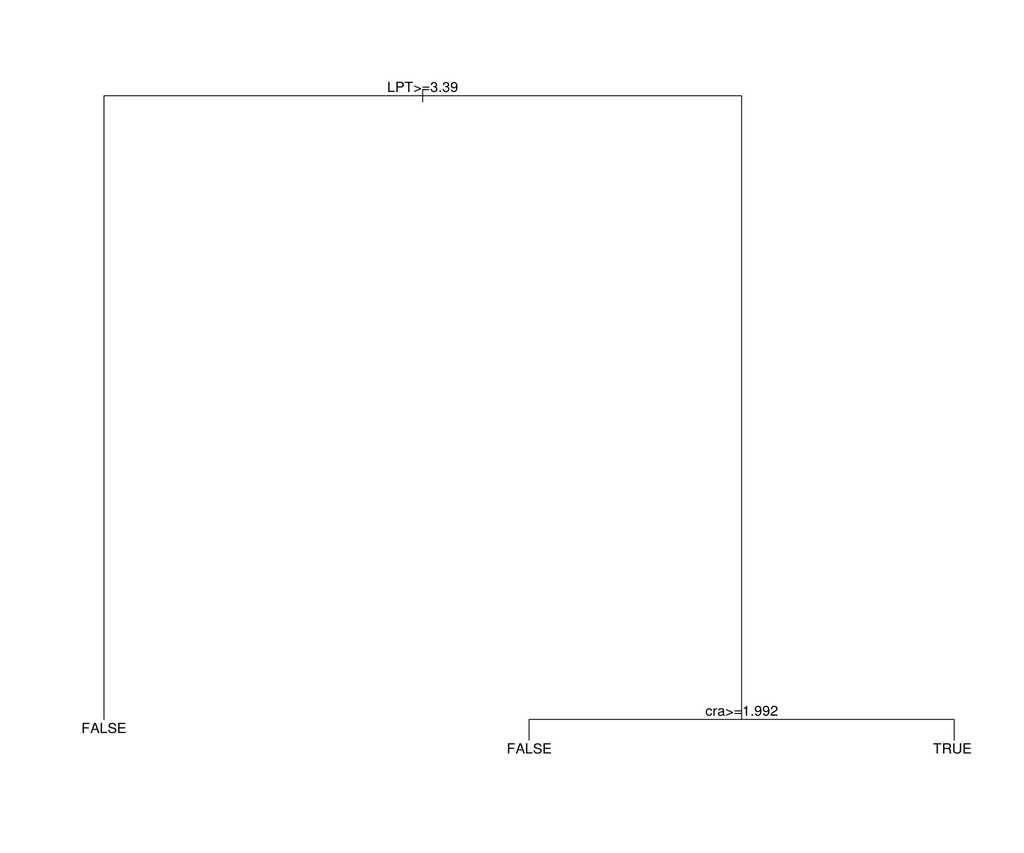

```r
model.rp.cc <- rpart(evadiu ~ AV + C1 + LPT + LP1 + P1 + IC + cra + cra_cc + num_NA + status + num_finais, data = treino, method = 'class')

plot(model.rp.cc)
text(model.rp.cc, pretty=0)
```

```r
pred.rp.cc <- predict(model.rp.cc, teste, type='class')

acc.rp.cc <- confusionMatrix(pred.rp.cc, teste$evadiu)
acc.rp.cc
```

```
## Confusion Matrix and Statistics
##
##           Reference
## Prediction FALSE TRUE
##      FALSE   170    4
##      TRUE      2   13
##
##                Accuracy : 0.9683
##                  95% CI : (0.9322, 0.9883)
##     No Information Rate : 0.9101
##     P-Value [Acc > NIR] : 0.001442
##
##                   Kappa : 0.7952
##  Mcnemar's Test P-Value : 0.683091
##
##             Sensitivity : 0.9884
##             Specificity : 0.7647
##          Pos Pred Value : 0.9770
##          Neg Pred Value : 0.8667
##              Prevalence : 0.9101
##          Detection Rate : 0.8995
##    Detection Prevalence : 0.9206
##       Balanced Accuracy : 0.8765
##
##        'Positive' Class : FALSE
##
```

# 7.2.3 Conclusão

Utilizando apenas a acurácia como parâmetro de comparação o modelo computação se saiu melhor com acurácia de ~0.97.

# 8. Reporte acurácia, precision e recall da validação-cruzada no teste (para os melhores modelos)

Considerando apenas os novos modelos (que utilizam métodos para controle de overfitting) e apenas os dados de teste como parâmetro, obtivemos o seguinte resultado.

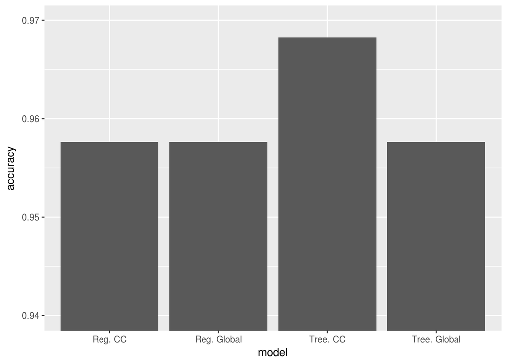

```r
# Acurácia
df <- data_frame('accuracy' = c(acc.ctr.reg.global$overall['Accuracy'],
                                acc.ctr.reg.cc$overall['Accuracy'],
                                acc.rp.global$overall['Accuracy'],
                                acc.rp.cc$overall['Accuracy']),
                 'model' = c('Reg. Global', 'Reg. CC', 'Tree. Global', 'Tree. CC'))

ggplot(data = df, aes(x=model, y=accuracy)) + geom_bar(stat="identity") + coord_cartesian(ylim=c(0.94, 0.97))
```

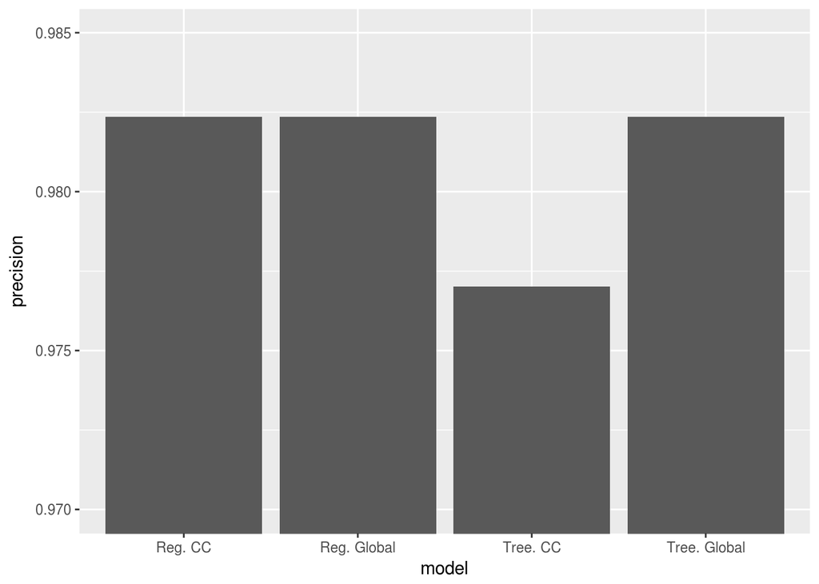

```r
# Precisão
df <- data_frame('precision' = c(acc.ctr.reg.global$byClass['Precision'],
                                acc.ctr.reg.cc$byClass['Precision'],
                                acc.rp.global$byClass['Precision'],
                                acc.rp.cc$byClass['Precision']),
                 'model' = c('Reg. Global', 'Reg. CC', 'Tree. Global', 'Tree. CC'))


ggplot(data = df, aes(x=model, y=precision)) + geom_bar(stat="identity") + coord_cartesian(ylim=c(0.97, 0.985))
```

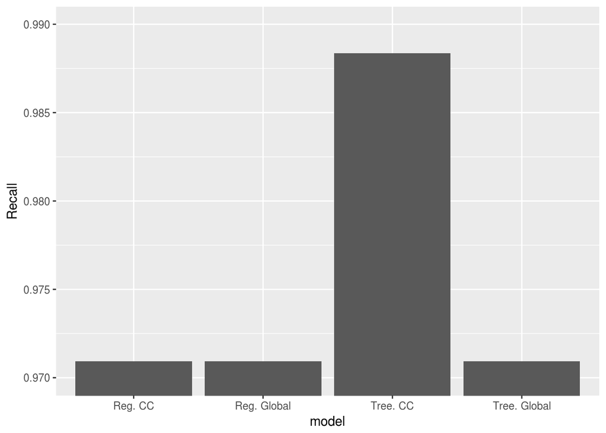

```r
# Recall
df <- data_frame('Recall' = c(acc.ctr.reg.global$byClass['Recall'],
                                acc.ctr.reg.cc$byClass['Recall'],
                                acc.rp.global$byClass['Recall'],
                                acc.rp.cc$byClass['Recall']),
                 'model' = c('Reg. Global', 'Reg. CC', 'Tree. Global', 'Tree. CC'))


ggplot(data = df, aes(x=model, y=Recall)) + geom_bar(stat="identity") + coord_cartesian(ylim=c(0.97, 0.99))
```

## Conclusão

# 9. Aplique o melhor modelo a você mesmo(a) usando seu histórico e reporte a predição e resultado.

Como visto nas análises anteriores vários modelos obtiveram resultados bastante similares, dito isso irei utilizar dois modelos para esta seção, um que apresentou resultados similares aos demais, e outro que apresentou um resultado mais singular.

Segue abaixo o resultado usando ambos classificadores.

```r
teste.marianne <- data.frame(C1 = 8.3, AV = 10, LPT = 9.2, P1 = 10, IC=9.9, LP1 = 10, num_NA = 0, status=as.factor(FALSE), cra=9.56, cra_cc=9.96, num_finais = 0)

pred.marianne.1 <- predict(model.reg.global, newdata = teste.marianne)
pred.marianne.2 <- predict(model.rp.cc, newdata = teste.marianne)

pred.marianne.1
```

```
## [1] FALSE
## Levels: FALSE TRUE
```

```r
pred.marianne.2
```

```
##      FALSE       TRUE
## 1 0.967128 0.03287197
```

Ambos os modelos previram a não evasão como esperado, além disso o segundo modelo além de prever afirma que há a probabilidade de ~0.967 de não evasão que é um valor bem alto (próximo de 100%) e indica o “quão certo” desta classificação o modelo está.

# Referências

[1. sobre C5.0](http://www.euclidean.com/machine-learning-in-practice/2015/6/12/r-caret-and-parameter-tuning-c50)

[2. cross validation linear regression](https://www.r-bloggers.com/evaluating-logistic-regression-models/)

[3. logistic regression in r](https://www.r-bloggers.com/how-to-perform-a-logistic-regression-in-r/)

[4. rpart](https://cran.r-project.org/web/packages/rpart/rpart.pdf)